# 3.1 Statistical analysis of chemical genomics data

gDR team

2026-10-06

3.1. Statistical analysis of chemical genomics data

**gDR Analysis Pipeline**

Date: 2026-10-06

Author: [gDR team](https://github.com/gdrplatform)

# 1 Introduction

This report performs a statistical analysis on the chemical genomics data to identify drug classes (e.g., grouped by Mechanism of Action, MOA) that show a differential response between experimental conditions. The analysis uses Gene Set Enrichment Analysis (GSEA), a method for determining whether a defined set of genes—or in this case, a set of drugs—shows statistically significant, concordant differences between two biological states.

```r
library(qs2)
library(data.table)
library(writexl)
library(gDRutils)
library(gDRplots)

# writexl cannot write list-columns (e.g. the GSEA leadingEdge gene lists);
# flatten any list-column to a comma-separated string before writing.
write_xlsx_flat <- function(x, path) {
  x <- as.data.frame(x, check.names = FALSE)
  for (j in which(vapply(x, is.list, logical(1)))) {
    x[[j]] <- vapply(x[[j]], function(v) paste(unlist(v), collapse = ", "), character(1))
  }
  writexl::write_xlsx(x, path = path)
}
```

# 2 Key Output Files

This report generates the **`tables`** folder, which contains Excel files detailing the GSEA results.

### 2.0.1 GSEA Results (in `tables/` folder):

- **`cgs_tables_RV_...xlsx` / `cgs_tables_GR_...xlsx`:** These files contain the full GSEA results for each analysis. Each sheet in the Excel file corresponds to a specific cell line (or cell line comparison) and metric.
- **Key columns:**
- `pathway`: The drug MOA being tested.
- `padj`: The adjusted p-value (FDR) for the enrichment.
- `NES`: The Normalized Enrichment Score. A positive score indicates enrichment at the top of the ranked list (e.g., sensitization), while a negative score indicates enrichment at the bottom (e.g., rescue).
- `leadingEdge`: A comma-separated list of the drugs within the `pathway` that contribute most to the enrichment score.

# 3 Read the gDR MAE data

This section loads the final `MultiAssayExperiment` (MAE) object, which contains all the processed data and results from the previous step.

```r
wd <- getwd()
mae <- qs_read(file.path(wd, "gDR_data", "gDR_mae.qs2"))
```

# 4 Preparing assay data

The relevant data assays are extracted from the MAE object to prepare for the GSEA analysis.

```r
combo_name <- get_supported_experiments("combo")
response_metrics_combo <-
  convert_se_assay_to_dt(mae[[combo_name]], "Metrics", unify_metadata = TRUE, merge_additional_variables = TRUE)
response_data_combo <-
  convert_se_assay_to_dt(mae[[combo_name]], "Averaged", unify_metadata = TRUE, merge_additional_variables = TRUE)

response_metrics_combo_capped <-
  cap_assay_infinities(conc_assay_dt = response_data_combo,
                       assay_dt = response_metrics_combo,
                       experiment_name = combo_name,
                       col = "xc50",
                       capping_fold = 5)
```

# 5 GSEA: Comparing Co-treatment vs. Single-Agent Response

This first analysis aims to identify drug classes (MOAs) that are significantly sensitized or rescued by the co-treatment. For each cell line, it ranks all drugs based on the difference in their response as single agents versus their response in the combination. GSEA is then performed on this ranked list to see if any drug MOA is enriched at the top (sensitized) or bottom (rescued) of the list.

The tables show the GSEA results for each cell line, with each row representing a drug MOA.

**What to look for:**

- **padj (Adjusted p-value):** This is the most important column for significance. A low value (e.g., < 0.05) indicates that the enrichment of the drug set is statistically significant.
- **NES (Normalized Enrichment Score):** This indicates the direction of the effect. A **positive NES** means the drug class is enriched among drugs that were **sensitized** by the co-treatment. A **negative NES** means the drug class is enriched among drugs that were **rescued** by the co-treatment.
- **leadingEdge:** This lists the specific drugs within the MOA that contributed most to the enrichment score.

```r
# Run GSEA
analyzed_metrics <- c("x_mean", "x_AOC_range", "xc50", "ec50", "x_max")
cgs_analysis_RV <- analyze_cgs(response_metrics_combo_capped,
                               metrics = analyzed_metrics,
                               normalization_type = "RV")
```

## 5.1 Relative Viability

### 5.1.1 NCI-H23

💾 Download Table

#### 5.1.1.1 x_mean

|  | pathway | pval | padj | log2err | ES | NES | size | leadingEdge | median |
| --- | --- | --- | --- | --- | --- | --- | --- | --- | --- |
| 1 | MAP2K1\|MAP2K2 | 0.0004979599704436663 | 0.005571843864138942 | 0.2611794047222205 | 0.8772381798732176 | 1.740163867782119 | 7 | ['Ro 5126766', 'PD901', 'Pimasertib', 'Trametinib', 'Cobimetinib', 'RG 7421'] | 0.1923032908629438 |
| 2 | MAPK1\|MAPK3 | 0.01919666823927508 | 0.1460484666078564 | 0.04175890380011975 | 0.7980769230769231 | 1.516142405993412 | 6 | ['SCH772984', 'G00548', 'Ravoxertinib', 'GDC-0535', 'G00386', 'VX11e'] | 0.1328007315364449 |
| 3 | BRAF\|RAF1\|ARAF | 0.07316869122912693 | 0.4076541368479929 | 0.021335414251052 | 0.7954449622613802 | 1.359852790910885 | 4 | ['Belvarafenib', 'AZD-628', 'Lifirafenib'] | 0.216786833793441 |
| 4 | RIPK1 | 0.1473580296489643 | 0.6700506177440432 | 0.0146809755688538 | 0.7441942893721754 | 1.272237212371908 | 4 | ['GSK481'] | 0.02002536976822689 |
| 5 | SMARCA4 | 0.1595221363316936 | 0.6700506177440432 | 0.01405375447468287 | 0.7378952553284794 | 1.261468699865384 | 4 | ['PFI-3', 'ColCN1213-19', 'G00643'] | 0.09851666666666675 |
| 6 | KRAS | 0.1879259820223239 | 0.6700506177440432 | 0.01270947329339041 | 0.6857898177471646 | 1.241602594931886 | 5 | ['Adagrasib', 'GDC-6036'] | 0.05228162210747223 |
| 7 | PPARG | 0.2284409195863869 | 0.7009318099502815 | 0.01147343611851839 | 0.7031403181591844 | 1.202053403333444 | 4 | ['Troglitazone', 'Rosiglitazone'] | 0.09238642508389427 |
| 8 | MDM2 | 0.2336439366500938 | 0.7009318099502815 | 0.01121826572270146 | 0.66365239487813 | 1.201523432238002 | 5 | ['AMG-232'] | 0.05829162665407062 |
| 9 | BRPF1 | 0.3186761703978851 | 0.7933336646209656 | 0.009405872824145506 | 0.6642817218033513 | 1.135622696983712 | 4 | ['GSK6853'] | 0.0327665579332459 |
| 10 | EGFR | 0.3563747580081016 | 0.7933336646209656 | 0.008614071703886839 | 0.5826180070269218 | 1.106825471839565 | 6 | ['EAI045', 'gefitinib'] | -0.0129625371170134 |

[output cut: 29 more lines]

#### 5.1.1.2 x_AOC_range

|  | pathway | pval | padj | log2err | ES | NES | size | leadingEdge | median |
| --- | --- | --- | --- | --- | --- | --- | --- | --- | --- |
| 1 | MTOR | 0.000262860144669563 | 0.005125772821056478 | 0.4984931087665903 | 0.9714285714285714 | 1.7598554653309 | 4 | ['Everolimus', 'AZD-8055', 'RG-7603', 'ASP7486'] | 0.2795449201930059 |
| 2 | PIK3CA | 0.0009369991369744791 | 0.01129946985575145 | 0.235539956233164 | 0.9523809523809523 | 1.725348495422451 | 4 | ['Inavolisib', 'Paxalisib', 'GDC-0326', 'Pictilisib'] | 0.2705225332478634 |
| 3 | TEAD1\|TEAD2\|TEAD3\|TEAD4 | 0.001158919985205277 | 0.01129946985575145 | 0.2115137935499351 | 0.9500386800955487 | 1.721105197660785 | 4 | ['SJN 2511', 'G00836', 'GNE-7883'] | 0.2087795479217686 |
| 4 | HSP90AA1\|HSP90AB1 | 0.02482858923748182 | 0.1613858300436318 | 0.04644878579220047 | 0.7953007817386949 | 1.622710181589974 | 6 | ['BIIB021', 'Geldanamycin', 'Tanespimycin', 'Ganetespib', 'Alvespimycin'] | 0.05183867481498672 |
| 5 | NR3C1 | 0.2149906503220445 | 0.7306566621200445 | 0.01518668495355727 | 0.6169553023240861 | 1.258818894253459 | 6 | ['Betamethasone', 'Dexamethasone acetate', 'Fluticasone'] | 0.01585555555555551 |
| 6 | BRD9 | 0.2818887929971644 | 0.7306566621200445 | 0.01269880087805421 | 0.6698855753151497 | 1.213575372948956 | 4 | ['G00570'] | 0.002993633079641289 |
| 7 | NAMPT | 0.4695351991123166 | 0.8620048105806936 | 0.009407093100692156 | 0.5526857428203424 | 1.001254290557343 | 4 | ['G00466', 'GMX1778'] | 0.01419921226472709 |
| 8 | ITK | 0.504574035260757 | 0.8620048105806936 | 0.008994591417258908 | 0.5333333333333333 | 0.9661951574365725 | 4 | ['G00572', 'GNE-4997', 'G00574', 'ITK inhibitor 2'] | 0.01001240863516278 |
| 9 | BTK | 0.5578121753584043 | 0.906444784957407 | 0.008723284387583592 | 0.4481946083962884 | 0.914484143707717 | 6 | ['Spebrutinib', 'Fenebrutinib'] | 0.024725279600123 |
| 10 | KDM2B | 0.6062877573665393 | 0.942606046215046 | 0.007989863790292609 | 0.4809523809523809 | 0.8713009901883376 | 4 | ['US10202354 Example 32', 'G00592', 'G00606', 'BDBM383547'] | -0.0009903440417075582 |

[output cut: 29 more lines]

#### 5.1.1.3 xc50

|  | pathway | pval | padj | log2err | ES | NES | size | leadingEdge | median |
| --- | --- | --- | --- | --- | --- | --- | --- | --- | --- |
| 1 | MAP2K1\|MAP2K2 | 0.01153019023986766 | 0.1416076063086444 | 0.05447487300525542 | 0.9130434782608696 | 1.451290129402397 | 7 | ['Ro 5126766', 'PD901', 'Pimasertib', 'Trametinib', 'Refametinib', 'Cobimetinib', 'RG 7421'] | 0.7609716856414626 |
| 2 | ESR1 | 0.01273779983457403 | 0.1416076063086444 | 0.05180751892686149 | 0.9104212160260232 | 1.447122021980628 | 7 | ['Giredestrant', 'Brilanestrant'] | 0 |
| 3 | EGFR | 0.0348916157451107 | 0.2721546028118635 | 0.03110074228514405 | 0.8929798929070715 | 1.376342065209575 | 6 | ['G00562', 'Mavelertinib', 'gefitinib'] | 0.286330267642439 |
| 4 | DNA | 0.1257233574025708 | 0.4903210938700261 | 0.0161804917605767 | 0.654100890622713 | 1.295159937642123 | 20 | ['Carboplatin', 'Cytarabine', 'Floxuridine', 'clofarabine', 'Mechlorethamine', 'Methotrexate', 'Gemcitabine', 'Melphalan'] | 0.009033092842478108 |
| 5 | BRAF\|RAF1\|ARAF | 0.09233644236063604 | 0.4858487811389385 | 0.01885009560689949 | 0.8904761904761904 | 1.273859875400568 | 4 | ['Belvarafenib', 'AZD-628', 'Lifirafenib'] | 0.6156111094807108 |
| 6 | BRAF | 0.09966128843875662 | 0.4858487811389385 | 0.01810189213876979 | 0.8857142857142857 | 1.267047790505378 | 4 | ['Encorafenib', 'Dabrafenib', 'Vemurafenib'] | 0.6245695327216036 |
| 7 | MAPK1\|MAPK3 | 0.1431599516452217 | 0.5075671012876041 | 0.01483105520834977 | 0.8125 | 1.252299113188604 | 6 | ['SCH772984', 'Ravoxertinib', 'G00548', 'VX11e', 'G00386', 'GDC-0535'] | 0.3786726111329444 |
| 8 | PPARG | 0.1238049154889627 | 0.4903210938700261 | 0.0161156218056481 | 0.8714285714285714 | 1.246611535819808 | 4 | ['Rosiglitazone', 'Troglitazone'] | 0.2288587002323558 |
| 9 | KRAS | 0.4305940544757415 | 0.9195362903225806 | 0.007708410472573685 | 0.7192838136254893 | 1.069583108288249 | 5 | ['Adagrasib', 'GDC-6036'] | 0.133243735539287 |
| 10 | PIK3C3 | 0.5099009079290255 | 0.9195362903225806 | 0.006851307432606428 | 0.6889952153110048 | 1.024543622459129 | 5 | ['MLN Ex I-299', 'Novartis VPS34 Cpd19', 'Vps34-IN-2', 'Vps34-IN-1', 'SAR405'] | 0.1528442495959215 |

[output cut: 29 more lines]

#### 5.1.1.4 ec50

|  | pathway | pval | padj | log2err | ES | NES | size | leadingEdge | median |
| --- | --- | --- | --- | --- | --- | --- | --- | --- | --- |
| 1 | DNA | 0.1330990018984606 | 0.8925887082677854 | 0.01652707849753192 | 0.8945504408944911 | 1.300749641030681 | 20 | ['Carboplatin', 'clofarabine'] | 0.0004141490676461226 |
| 2 | BTK | 0.1250101667344449 | 0.8925887082677854 | 0.01782576856405154 | 0.9482166772630392 | 1.252226497815512 | 6 | ['GDC-1020', 'GDC-0852', 'Ibrutinib'] | 5.196956626856053 |
| 3 | BRPF1 | 0.2059820096002582 | 0.8925887082677854 | 0.01352746961804423 | 0.9258710709910193 | 1.191354098376524 | 4 | ['PFI-4', 'GSK6853', 'G00217'] | 16.32778193666914 |
| 4 | RIPK1 | 0.2400871283933686 | 0.9363398007341374 | 0.01241128289234206 | 0.9139893172283944 | 1.176065386498041 | 4 | ['Necrostatin'] | 0.9301885061252886 |
| 5 | ESR1 | 0.3722706314870107 | 0.9672036869263796 | 0.009630771817755769 | 0.8429615231702526 | 1.125752647013929 | 7 | ['Raloxifene hydrochloride', 'SRN-927'] | -2.201746694473004 |
| 6 | ERN1 | 0.3991771207292969 | 0.9672036869263796 | 0.009184291276011752 | 0.8517551842990196 | 1.095986321877348 | 4 | ['G00215'] | 0.3018412830362065 |
| 7 | MDM2 | 0.4346634732483559 | 0.9672036869263796 | 0.00873961046012431 | 0.8317321288107384 | 1.083499605848065 | 5 | ['AMG-232', 'Nutlin-3a', 'Idasanutlin'] | 1.250240359163097 |
| 8 | kinases (multiple) | 0.4589467263115087 | 0.9672036869263796 | 0.008450015251150895 | 0.813044221527794 | 1.073716105723439 | 6 | ['H-89', 'Ponatinib'] | -0.04205306786269226 |
| 9 | MAPK14 | 0.4631116130853939 | 0.9672036869263796 | 0.008356581319508156 | 0.8260040835310565 | 1.062851385060733 | 4 | ['SB 203580'] | 0 |
| 10 | MAPK1\|MAPK3 | 0.5999593330622204 | 0.971157749451977 | 0.007051818426164543 | 0.744157487879447 | 0.9827434458969863 | 6 | ['Ravoxertinib', 'VX11e', 'G00386', 'SCH772984'] | 0.437575697395016 |

[output cut: 29 more lines]

#### 5.1.1.5 x_max

|  | pathway | pval | padj | log2err | ES | NES | size | leadingEdge | median |
| --- | --- | --- | --- | --- | --- | --- | --- | --- | --- |
| 1 | MAP2K1\|MAP2K2 | 0.04029692470837752 | 0.4164605185038591 | 0.02844721117084307 | 0.8160044523162635 | 1.438423606587303 | 7 | ['Refametinib', 'Pimasertib', 'PD901', 'Ro 5126766'] | 0.1135 |
| 2 | MDM2 | 0.04271389933372914 | 0.4164605185038591 | 0.02798140346544281 | 0.8621174836475824 | 1.414336152649551 | 5 | ['AMG-232', 'Idasanutlin'] | 0.01490000000000002 |
| 3 | kinases (multiple) | 0.08915012275823944 | 0.5359852232996899 | 0.01894267875015635 | 0.7931842224573069 | 1.354363433851555 | 6 | ['H-89'] | 0.02725 |
| 4 | ESR1 | 0.1091134033869983 | 0.5359852232996899 | 0.01690261229870071 | 0.756373548455161 | 1.333308371550934 | 7 | ['Brilanestrant', 'Toremifene', 'Giredestrant'] | 0.06500000000000017 |
| 5 | BRAF | 0.1143129994806239 | 0.5359852232996899 | 0.01686003115584328 | 0.8348532745793018 | 1.308280063941077 | 4 | ['Dabrafenib', 'Encorafenib'] | 0.2505500000000001 |
| 6 | KRAS | 0.1236888976845438 | 0.5359852232996899 | 0.01602250855116031 | 0.7973560759241717 | 1.308092627866634 | 5 | ['GDC-6036'] | 0.0111 |
| 7 | ERN1 | 0.2954747264898554 | 0.7831618098977738 | 0.009859409748878462 | 0.737656492303037 | 1.155965140584829 | 4 | ['G00215', 'G00735'] | 0.05575000000000001 |
| 8 | PPARG | 0.3027794997235579 | 0.7831618098977738 | 0.009713934687545342 | 0.7343102661499206 | 1.150721343741885 | 4 | ['Rosiglitazone', 'Troglitazone'] | 0.1441 |
| 9 | HDAC1\|HDAC2 | 0.3718467817089238 | 0.7831618098977738 | 0.008314054298123371 | 0.6278248965866144 | 1.106707383139875 | 7 | ['BDBM50276074', 'Vorinostat', 'Entinostat', 'BRD-6929'] | 0.0384 |
| 10 | BRAF\|RAF1\|ARAF | 0.3815403689245565 | 0.7831618098977738 | 0.00840147407817488 | 0.698445656636753 | 1.094518709032507 | 4 | ['Belvarafenib', 'AZD-628'] | 0.1034 |

[output cut: 29 more lines]

### 5.1.2 NCI-H358

💾 Download Table

#### 5.1.2.1 x_mean

|  | pathway | pval | padj | log2err | ES | NES | size | leadingEdge | median |
| --- | --- | --- | --- | --- | --- | --- | --- | --- | --- |
| 1 | CHEK1 | 0.001422672197458471 | 0.02774210785044018 | 0.4550598673872295 | 0.7391304347826086 | 2.179216876577219 | 7 | ['Prexasertib', 'G00212', 'AZD7762', 'Rabusertib', 'RG7741', 'PF 477736', 'GDC-0425'] | -0.0993024050644925 |
| 2 | MAPK1\|MAPK3 | 0.004958262725161615 | 0.03554432077588764 | 0.1627669573721343 | 0.7115384615384616 | 1.953268141316429 | 6 | ['SCH772984', 'Ravoxertinib', 'GDC-0535', 'G00386', 'VX11e', 'G00548'] | -0.06867541175759356 |
| 3 | ESR1 | 0.005284015852047556 | 0.03554432077588764 | 0.1705542951977495 | 0.6570048309178744 | 1.937081668068639 | 7 | ['Raloxifene hydrochloride', 'Tamoxifen', 'fulvestrant', 'Brilanestrant', 'Giredestrant', 'Toremifene', 'SRN-927'] | -0.1387976216724661 |
| 4 | 20S proteasome | 0.04154091958104029 | 0.2122199209188477 | 0.04694741219567284 | 0.6952380952380952 | 1.575369106020872 | 4 | ['MG-132', 'Bortizomib', 'Carfilzomib', 'AM 114'] | -0.07966147108898272 |
| 5 | MAP2K1\|MAP2K2 | 0.04726258623220314 | 0.2122199209188477 | 0.05668894419796588 | 0.5227977216322593 | 1.541391836140834 | 7 | ['PD901', 'RG 7421', 'Trametinib', 'Pimasertib'] | 0.07192550658592345 |
| 6 | EGFR | 0.05441536433816607 | 0.2122199209188477 | 0.04879782446162299 | 0.5576923076923077 | 1.530939894545309 | 6 | ['Erlotinib', 'Mavelertinib', 'EAI045', 'osimertinib', 'G00562', 'gefitinib'] | -0.1773912912004746 |
| 7 | NAMPT | 0.09462098349014735 | 0.283862950470442 | 0.03091386856160313 | 0.6238095238095238 | 1.413516115676262 | 4 | ['GNE-617', 'GNE-618', 'GMX1778', 'G00466'] | -0.1077148070614464 |
| 8 | SMARCA4 | 0.2882123202556364 | 0.4887078473899922 | 0.01731235273527477 | 0.5 | 1.132970932412271 | 4 | ['PFI-3', 'G00648', 'G00643', 'ColCN1213-19'] | -0.2024629117349824 |
| 9 | MDM2 | 0.4915505641786301 | 0.7100174815913546 | 0.01426562734257788 | 0.3827751196172249 | 0.9649096131709153 | 5 | ['AMG-232', 'NSC 66811', 'Serdemetan', 'Idasanutlin', 'Nutlin-3a'] | -0.1526039387238536 |
| 10 | ITK | 0.9367566128173265 | 0.9614081026283088 | 0.00882038069403986 | 0.2761904761904762 | 0.625831562665826 | 4 | ['ITK inhibitor 2', 'G00574', 'G00572', 'GNE-4997'] | -0.1842214122677624 |

[output cut: 29 more lines]

#### 5.1.2.2 x_AOC_range

|  | pathway | pval | padj | log2err | ES | NES | size | leadingEdge | median |
| --- | --- | --- | --- | --- | --- | --- | --- | --- | --- |
| 1 | TEAD1\|TEAD2\|TEAD3\|TEAD4 | 4.458310207352188e-05 | 0.001738740980867353 | 0.557332238758646 | 0.9571428571428572 | 1.94036824473385 | 4 | ['G00836', 'SJN 2511', 'GNE-7883', 'TEAD-PPI'] | 0.5597029114573568 |
| 2 | PIK3C3 | 0.001394700139470014 | 0.01813110181311018 | 0.1359416132348814 | 0.8490881651065281 | 1.842882315422517 | 5 | ['Vps34-IN-2', 'SAR405', 'Novartis VPS34 Cpd19', 'Vps34-IN-1'] | 0.410796791105251 |
| 3 | PIK3CA | 0.003474374870841083 | 0.03387515499070056 | 0.08792620334136504 | 0.861904761904762 | 1.747296777596154 | 4 | ['Paxalisib', 'GDC-0326', 'Inavolisib', 'Pictilisib'] | 0.3877395807702138 |
| 4 | MTOR | 0.077947406488944 | 0.323394495412844 | 0.01800272207201668 | 0.694123013872835 | 1.407161160955913 | 4 | ['Everolimus', 'RG-7603', 'AZD-8055'] | 0.353169852844449 |
| 5 | PIM1\|PIM2 | 0.08658249095913405 | 0.323394495412844 | 0.01661054476800781 | 0.6414153425204194 | 1.392143996522734 | 5 | ['GDC-0570', 'G00194', 'GDC-0339', 'G00600'] | 0.3298394341047161 |
| 6 | HMGCR | 0.1399625749395121 | 0.3784426259858555 | 0.01250749130147221 | 0.5695229694068047 | 1.305473203357691 | 6 | ['Mibefradil', 'Lovastatin', 'Atorvastatin', 'Simvastin', 'Mevastatin'] | 0.2751629303632877 |
| 7 | RIPK1 | 0.1399695184955569 | 0.3784426259858555 | 0.01308650595060743 | 0.6428544642983804 | 1.303226973070116 | 4 | ['GDC-7731', 'GSK2606414', 'Necrostatin'] | 0.2736845215835123 |
| 8 | PLK1 | 0.145554856148406 | 0.3784426259858555 | 0.01247741150014779 | 0.5980861244019139 | 1.298101171415567 | 5 | ['SBE13', 'Rigosertib', 'BI 2536', 'G00792', 'GSK-461364'] | 0.2926926299425101 |
| 9 | MET | 0.1908710477371358 | 0.4652481788592685 | 0.01095598371754254 | 0.6114734806863453 | 1.23960986133502 | 4 | ['GDC-0712', 'Tepotinib', 'PF-04217903'] | 0.3161492832390136 |
| 10 | kinases (multiple) | 0.2617012908070225 | 0.5342068166386208 | 0.008601251710971857 | 0.5097454713433529 | 1.168449894241846 | 6 | ['Ponatinib', 'BAY 11-7821', 'Alvocidib'] | 0.2535695611288252 |

[output cut: 29 more lines]

#### 5.1.2.3 xc50

|  | pathway | pval | padj | log2err | ES | NES | size | leadingEdge | median |
| --- | --- | --- | --- | --- | --- | --- | --- | --- | --- |
| 1 | MAP2K1\|MAP2K2 | 0.01257014590347924 | 0.1634118967452301 | 0.1365505315616176 | 0.9227053140096618 | 2.01444907253348 | 7 | ['PD901', 'Ro 5126766', 'RG 7421', 'Trametinib', 'Cobimetinib', 'Pimasertib'] | 0.3048368413744675 |
| 2 | CHEK1 | 0.01907968574635241 | 0.186026936026936 | 0.110718624505367 | 0.9048789946899234 | 1.975530674779507 | 7 | ['Prexasertib', 'G00212', 'AZD7762', 'RG7741', 'Rabusertib', 'GDC-0425'] | 0.1474756182708263 |
| 3 | EGFR | 0.0439344262295082 | 0.3426885245901639 | 0.06649667625343997 | 0.8953244609380328 | 1.828234001723943 | 6 | ['gefitinib', 'Mavelertinib'] | 0 |
| 4 | NR3C1 | 0.08543325526932084 | 0.4494299374770136 | 0.04756722515884873 | 0.7836538461538461 | 1.600204919699346 | 6 | ['Dexamethasone acetate', 'Betamethasone', 'Cortisone', 'Mometasone furoate', 'Fluticasone', 'Dexamethasone'] | 0 |
| 5 | PPARG | 0.09219075640554125 | 0.4494299374770136 | 0.03692608205354719 | 0.919047619047619 | 1.568492976100287 | 4 | ['Rosiglitazone', 'Troglitazone'] | 0.0609934997150805 |
| 6 | BRAF\|RAF1\|ARAF | 0.1636631114380287 | 0.7080233711302021 | 0.02754761982014867 | 0.8761904761904762 | 1.495350816593019 | 4 | ['Lifirafenib', 'AZD-628'] | 0.004522730375168982 |
| 7 | SMARCA4 | 0.3362142944710065 | 0.7754053505072109 | 0.0189390242002702 | 0.6238095238095238 | 1.064624766161334 | 4 | ['PFI-3', 'G00643', 'ColCN1213-19', 'G00648'] | 0 |
| 8 | DPP4 | 0.3590167953904622 | 0.7754053505072109 | 0.01829155815703854 | 0.6047619047619048 | 1.03211713971366 | 4 | ['sitagliptin', 'Vildagliptin', 'Saxagliptin', 'Alogliptin'] | 0 |
| 9 | ESR1 | 0.4245791245791246 | 0.7754053505072109 | 0.02300976304076123 | 0.4405152506027607 | 0.9617323370094875 | 7 | ['Brilanestrant'] | 0 |
| 10 | ERN1 | 0.5008581586367538 | 0.7813387274733359 | 0.01529471637766537 | 0.5285714285714286 | 0.9020866339229627 | 4 | ['G00735', 'G00215', 'G00740', 'KIRA8'] | -0.03624282429233089 |

[output cut: 29 more lines]

#### 5.1.2.4 ec50

|  | pathway | pval | padj | log2err | ES | NES | size | leadingEdge | median |
| --- | --- | --- | --- | --- | --- | --- | --- | --- | --- |
| 1 | NR3C1 | 1.883707023539799e-06 | 7.346457391805215e-05 | 0.6435518361507222 | 1 | 1.363489535825302 | 6 | ['Dexamethasone'] | 0 |
| 2 | DPP4 | 0.01074712772893855 | 0.2095689907143018 | 0.06586404739673779 | 0.9939350246383005 | 1.314649162486927 | 4 | ['sitagliptin'] | 0.1304770808274466 |
| 3 | SMARCA4 | 0.07406075050025857 | 0.6748190666333916 | 0.02472142911216106 | 0.9715025223483356 | 1.284978339327515 | 4 | ['G00648'] | 1.934063083877315 |
| 4 | PPARG | 0.1525282730399982 | 0.6748190666333916 | 0.01691196608741744 | 0.9428571428571428 | 1.247089922857917 | 4 | ['Rosiglitazone', 'Troglitazone'] | 6.918843696135845 |
| 5 | TUBB | 0.2076366358871974 | 0.6748190666333916 | 0.01369917171420927 | 0.8858347543087552 | 1.244673444081752 | 9 | ['cryptophycin analog'] | -0.02703018788845612 |
| 6 | MAPK14 | 0.2045326798120377 | 0.6748190666333916 | 0.0144220762675933 | 0.9241114922114099 | 1.222295591930044 | 4 | ['SB 203580', 'S6005'] | 13.88543151018859 |
| 7 | BTK | 0.289659531801735 | 0.7206640905622659 | 0.01165400162666856 | 0.8776598679376988 | 1.196680045946869 | 6 | ['GDC-0852', 'Ibrutinib', 'Fenebrutinib'] | 10.4265982966466 |
| 8 | RIPK1 | 0.3107673629066708 | 0.7206640905622659 | 0.01139191115428624 | 0.8859933318061676 | 1.171877801621739 | 4 | ['GSK481'] | 0.03896081025577755 |
| 9 | CHEK1 | 0.5634024056979321 | 0.7847390650792625 | 0.007660357432150825 | 0.7240469170073802 | 0.9980001292253777 | 7 | ['Rabusertib', 'GDC-0425', 'AZD7762', 'RG7741', 'PF 477736', 'G00212'] | 0.1332855719836632 |
| 10 | BRAF\|RAF1\|ARAF | 0.751646918632102 | 0.8518961749210807 | 0.006437856553222204 | 0.6316587914217651 | 0.8354768476161905 | 4 | ['AZD-628', 'GDC-0879', 'Lifirafenib'] | 0.8134770820900139 |

[output cut: 29 more lines]

#### 5.1.2.5 x_max

|  | pathway | pval | padj | log2err | ES | NES | size | leadingEdge | median |
| --- | --- | --- | --- | --- | --- | --- | --- | --- | --- |
| 1 | CHEK1 | 0.005100225358794923 | 0.07709642984224883 | 0.2212471812228566 | 0.8024114106819961 | 2.048071886383084 | 7 | ['GDC-0425', 'RG7741'] | 0.001399999999999998 |
| 2 | MAP2K1\|MAP2K2 | 0.005930494603249911 | 0.07709642984224883 | 0.2050014994268661 | 0.7889003822468402 | 2.013586387889679 | 7 | ['PD901', 'Pimasertib', 'RG 7421', 'Trametinib'] | 0.0964 |
| 3 | NAMPT | 0.01739130434782609 | 0.1695652173913043 | 0.08380172756842354 | 0.8952380952380953 | 1.77513666475685 | 4 | ['GNE-617', 'G00466', 'GNE-618', 'GMX1778'] | 0.04005 |
| 4 | 20S proteasome | 0.07379553466509989 | 0.4301478845256811 | 0.04045969831364282 | 0.7571428571428571 | 1.501312392001804 | 4 | ['AM 114', 'MG-132', 'Carfilzomib', 'Bortizomib'] | -0.00265 |
| 5 | TUBB | 0.1887579329102448 | 0.586002175039464 | 0.04449203163741515 | 0.4195121951219513 | 1.188985455155712 | 9 | ['VINORELBINE', 'Vinblastine', 'cryptophycin analog', 'Docetaxel', 'SB-T-121-602', 'Paclitaxel', 'Vincristine', 'Tivantinib', 'Nocodozole'] | -0.052 |
| 6 | kinases (multiple) | 0.369268897149938 | 0.6261516082107645 | 0.02272711796673139 | 0.4375 | 1.039919768238836 | 6 | ['Staurosporine', 'BAY 11-7821', 'Ponatinib', 'Alvocidib', 'Midostaurin', 'H-89'] | -0.0254 |
| 7 | MAPK1\|MAPK3 | 0.4982365837384425 | 0.7308715403047849 | 0.01942730598629027 | 0.4038461538461539 | 0.959925939912772 | 6 | ['VX11e', 'GDC-0535', 'SCH772984', 'G00386', 'G00548', 'Ravoxertinib'] | 0.04919999999999999 |
| 8 | EGFR | 0.7035554284624916 | 0.8851181196786185 | 0.01616154772046746 | 0.3557692307692307 | 0.8456490423041085 | 6 | ['Erlotinib', 'gefitinib', 'osimertinib', 'Mavelertinib', 'EAI045', 'G00562'] | -0.0138 |
| 9 | TEAD1\|TEAD2\|TEAD3\|TEAD4 | 0.8658049353701528 | 0.9099390481336969 | 0.01097428950773592 | 0.3666666666666667 | 0.7270506552461565 | 4 | ['G00836', 'SJN 2511', 'TEAD-PPI', 'GNE-7883'] | -0.04529999999999999 |
| 10 | MDM2 | 0.8866072776687302 | 0.9099390481336969 | 0.01250688790713946 | 0.32992444239489 | 0.7203071959565599 | 5 | ['Idasanutlin', 'AMG-232'] | -0.003900000000000001 |

[output cut: 29 more lines]

```r
# Run GSEA
cgs_analysis_GR <- analyze_cgs(response_metrics_combo_capped,
                               metrics = analyzed_metrics,
                               normalization_type = "GR")
```

## 5.2 GR Value

### 5.2.1 NCI-H23

💾 Download Table

#### 5.2.1.1 x_mean

|  | pathway | pval | padj | log2err | ES | NES | size | leadingEdge | median |
| --- | --- | --- | --- | --- | --- | --- | --- | --- | --- |
| 1 | MAP2K1\|MAP2K2 | 0.0002911565042830654 | 0.003785034555679851 | 0.3353479565265869 | 0.8892817882648405 | 1.748796964678612 | 7 | ['Ro 5126766', 'PD901', 'Trametinib', 'Cobimetinib', 'RG 7421', 'Pimasertib'] | 0.2668980826838595 |
| 2 | MAPK1\|MAPK3 | 0.004410535764028599 | 0.03177720631870461 | 0.08541113991963023 | 0.8509615384615384 | 1.607131564777438 | 6 | ['SCH772984', 'G00548', 'GDC-0535', 'VX11e', 'Ravoxertinib', 'G00386'] | 0.2022155469164966 |
| 3 | TUBB | 0.07852280564968363 | 0.3827986775422077 | 0.01940772325002956 | 0.6585452212366834 | 1.383855349819845 | 9 | ['Vincristine', 'VINORELBINE', 'Nocodozole', 'cryptophycin analog', 'Vinblastine', 'Paclitaxel', 'Tivantinib', 'Docetaxel'] | 0.164520766688896 |
| 4 | KRAS | 0.06355398942864335 | 0.3540865125310129 | 0.0222360185854586 | 0.7646587311439672 | 1.376410593264313 | 5 | ['Adagrasib', 'GDC-6036'] | 0.07450042776702825 |
| 5 | DNA | 0.1365742351091509 | 0.5326395169256883 | 0.01382879676707188 | 0.5070036918976029 | 1.294836092069082 | 20 | ['Cytarabine', 'Floxuridine', 'Methotrexate', 'Carboplatin', 'Cytoxan', 'Melphalan', 'Gemcitabine', 'Mechlorethamine'] | 0.05268333333333342 |
| 6 | BRAF\|RAF1\|ARAF | 0.1329142343960485 | 0.5326395169256883 | 0.01517669240497454 | 0.7503421444139756 | 1.277340425802562 | 4 | ['AZD-628', 'Belvarafenib', 'Lifirafenib'] | 0.2706565199349313 |
| 7 | MDM2 | 0.1616536622199849 | 0.5731357115072192 | 0.01348120475036392 | 0.696565960090193 | 1.253841390055293 | 5 | ['AMG-232', 'Idasanutlin', 'Serdemetan'] | 0.1048316439379189 |
| 8 | HDAC1\|HDAC2 | 0.2056331121565503 | 0.6168993364696508 | 0.01158871479171965 | 0.6223807886261267 | 1.223928847286261 | 7 | ['Romidepsin', 'Entinostat', 'TSA', 'Vorinostat'] | 0.1100352548552959 |
| 9 | RIPK1 | 0.26930848675348 | 0.7502164988132657 | 0.01015542998522613 | 0.6821940641335931 | 1.161328952195469 | 4 | ['GSK481'] | 0.0352923498124737 |
| 10 | SMARCA4 | 0.3155911219449612 | 0.7602967771032397 | 0.009217108810579494 | 0.6628141230785373 | 1.128337626380195 | 4 | ['PFI-3', 'ColCN1213-19', 'G00643'] | 0.1017666666666667 |

[output cut: 29 more lines]

#### 5.2.1.2 x_AOC_range

|  | pathway | pval | padj | log2err | ES | NES | size | leadingEdge | median |
| --- | --- | --- | --- | --- | --- | --- | --- | --- | --- |
| 1 | HSP90AA1\|HSP90AB1 | 0.003250050782043469 | 0.02112533008328255 | 0.1365505315616176 | 0.8778990310024439 | 1.79992262524066 | 6 | ['BIIB021', 'Geldanamycin', 'Alvespimycin', 'Ganetespib', 'Tanespimycin'] | 0.1448648928350871 |
| 2 | MTOR | 3.16776589297528e-05 | 0.0006177143491301795 | 0.557332238758646 | 0.9857142857142858 | 1.786948650830902 | 4 | ['AZD-8055', 'Everolimus', 'RG-7603', 'ASP7486'] | 0.3676751028266705 |
| 3 | PIK3CA | 0.0006666488893629503 | 0.008666435561718354 | 0.2914124825948825 | 0.9619047619047619 | 1.743785639941267 | 4 | ['Paxalisib', 'Inavolisib', 'GDC-0326', 'Pictilisib'] | 0.3582098267081899 |
| 4 | TEAD1\|TEAD2\|TEAD3\|TEAD4 | 0.001653289245620117 | 0.01611957014479614 | 0.1839071474564402 | 0.9507510324730816 | 1.723565641054641 | 4 | ['SJN 2511', 'G00836', 'GNE-7883'] | 0.2345293625919045 |
| 5 | NR3C1 | 0.2206262151417545 | 0.7822202173207657 | 0.01590473816633341 | 0.6085810537684662 | 1.247750332654844 | 6 | ['Betamethasone', 'Dexamethasone acetate', 'Fluticasone'] | 0.01618333333333333 |
| 6 | BRD9 | 0.270099464014293 | 0.8237505776193331 | 0.01358980077518051 | 0.6752413268415685 | 1.224108847230966 | 4 | ['G00570'] | 0.003268451440304299 |
| 7 | ITK | 0.4768139516279566 | 0.8565627583264447 | 0.00977705580433118 | 0.5428571428571429 | 0.9841166482836854 | 4 | ['G00572', 'GNE-4997', 'G00574', 'ITK inhibitor 2'] | 0.00934687086630881 |
| 8 | BTK | 0.5468210440788137 | 0.8565627583264447 | 0.009467943542440703 | 0.4485267284607306 | 0.9195971040767621 | 6 | ['Spebrutinib', 'Fenebrutinib'] | 0.02542198014577118 |
| 9 | KDM2B | 0.5490786912349004 | 0.8565627583264447 | 0.008959372734509218 | 0.5047619047619047 | 0.9150558308602688 | 4 | ['US10202354 Example 32', 'G00592', 'G00606', 'BDBM383547'] | -0.004512638150371284 |
| 10 | ESR1 | 0.6266237635561912 | 0.9308930801693697 | 0.008840292773183567 | 0.4009661835748792 | 0.8631470158498424 | 7 | ['Giredestrant', 'SRN-927', 'fulvestrant', 'Tamoxifen', 'Toremifene', 'Brilanestrant', 'Raloxifene hydrochloride'] | -0.0112888888888889 |

[output cut: 29 more lines]

#### 5.2.1.3 xc50

|  | pathway | pval | padj | log2err | ES | NES | size | leadingEdge | median |
| --- | --- | --- | --- | --- | --- | --- | --- | --- | --- |
| 1 | MAP2K1\|MAP2K2 | 0.01028435334872979 | 0.200544890300231 | 0.06028197000083225 | 0.9130434782608696 | 1.466411136352483 | 7 | ['Ro 5126766', 'PD901', 'Pimasertib', 'Trametinib', 'Refametinib', 'Cobimetinib', 'RG 7421'] | 0.8263290014412918 |
| 2 | EGFR | 0.04476755651971243 | 0.4364836760671962 | 0.02851142220625374 | 0.8806696706573225 | 1.369770489374563 | 6 | ['G00562', 'Mavelertinib', 'gefitinib'] | 0.3222987583366695 |
| 3 | BRAF | 0.07190020700977942 | 0.4377721464772646 | 0.02226763227151471 | 0.9047619047619048 | 1.300473805373826 | 4 | ['Encorafenib', 'Dabrafenib', 'Vemurafenib'] | 0.7272475983262487 |
| 4 | BRAF\|RAF1\|ARAF | 0.07857448782925262 | 0.4377721464772646 | 0.02125926145949132 | 0.9 | 1.293629206398174 | 4 | ['Belvarafenib', 'AZD-628', 'Lifirafenib'] | 0.6603648187081529 |
| 5 | DNA | 0.1508512010632684 | 0.5519111335312554 | 0.0157759668867607 | 0.6242632909945811 | 1.271888686932456 | 20 | ['Carboplatin', 'Cytarabine', 'Floxuridine', 'clofarabine', 'Methotrexate', 'Mechlorethamine'] | 0 |
| 6 | MAPK1\|MAPK3 | 0.1351811678648905 | 0.5519111335312554 | 0.01597649372612783 | 0.8173076923076923 | 1.271218931414206 | 6 | ['SCH772984', 'Ravoxertinib', 'G00548', 'VX11e', 'G00386', 'GDC-0535'] | 0.390325137841401 |
| 7 | PPARG | 0.174173745449354 | 0.5660646727104005 | 0.01387271992532621 | 0.8476190476190476 | 1.218338617666006 | 4 | ['Troglitazone', 'Rosiglitazone'] | 0.1689409553842903 |
| 8 | ESR1 | 0.3968858256351039 | 0.8583662126295433 | 0.008591225105502307 | 0.6822733055272446 | 1.095778237381283 | 7 | ['Brilanestrant'] | 0 |
| 9 | MET | 0.4389856520808052 | 0.8583662126295433 | 0.00798749452446769 | 0.7422267200637621 | 1.06685129204845 | 4 | ['Tepotinib'] | 0.01678295130958285 |
| 10 | MAPK14 | 0.4600613891070026 | 0.8583662126295433 | 0.00774104530090749 | 0.7333333333333334 | 1.054068242250364 | 4 | ['Ralimetinib'] | 0 |

[output cut: 29 more lines]

#### 5.2.1.4 ec50

|  | pathway | pval | padj | log2err | ES | NES | size | leadingEdge | median |
| --- | --- | --- | --- | --- | --- | --- | --- | --- | --- |
| 1 | DNA | 0.09431030787913422 | 0.9466463825543155 | 0.01932220892755623 | 0.8970054913063131 | 1.31397196081962 | 20 | ['Carboplatin', 'clofarabine'] | 0 |
| 2 | BTK | 0.2287936049387602 | 0.9466463825543155 | 0.0126173176386653 | 0.9086538461538461 | 1.195134633015007 | 6 | ['GDC-1020', 'GDC-0852', 'Ibrutinib', 'Spebrutinib'] | 7.985132292765973 |
| 3 | BRPF1 | 0.2198256440395729 | 0.9466463825543155 | 0.0128329032005656 | 0.9207829013669893 | 1.180846477292166 | 4 | ['PFI-4', 'GSK6853'] | 16.10472851081295 |
| 4 | RIPK1 | 0.2600450582819081 | 0.9466463825543155 | 0.01166159321101466 | 0.9068008729496578 | 1.162915400403691 | 4 | ['Necrostatin'] | 4.792991489977891 |
| 5 | PPARG | 0.2905475560779704 | 0.9466463825543155 | 0.01093298821943426 | 0.8952380952380953 | 1.148086861224542 | 4 | ['Troglitazone', 'Rosiglitazone'] | 2.500096282773576 |
| 6 | ESR1 | 0.4220363506629933 | 0.9466463825543155 | 0.008771413071492623 | 0.824443382818003 | 1.097309599856997 | 7 | ['Raloxifene hydrochloride', 'SRN-927'] | -2.847617794128093 |
| 7 | MAPK14 | 0.4444117935155255 | 0.9466463825543155 | 0.008422548806143062 | 0.8369214463367013 | 1.073299406635125 | 4 | ['SB 203580'] | 0 |
| 8 | PARP1\|PARP2 | 0.5861690665099422 | 0.9466463825543155 | 0.006982100189299485 | 0.7742139596645543 | 0.9928809772456139 | 4 | ['Rucaparib'] | 0.3259399384284147 |
| 9 | HSP90AA1\|HSP90AB1 | 0.5923148459605453 | 0.9466463825543155 | 0.00697976999217126 | 0.7526387384119431 | 0.9899310130389727 | 6 | ['BIIB021'] | -0.005503071019457942 |
| 10 | KDM2B | 0.6214712508570869 | 0.9466463825543155 | 0.006693143646271384 | 0.7571065977950774 | 0.9709418556900945 | 4 | ['US10202354 Example 32'] | 0.2458662963677033 |

[output cut: 29 more lines]

#### 5.2.1.5 x_max

|  | pathway | pval | padj | log2err | ES | NES | size | leadingEdge | median |
| --- | --- | --- | --- | --- | --- | --- | --- | --- | --- |
| 1 | MDM2 | 0.005622870414228306 | 0.07309731538496798 | 0.0751183864552573 | 0.9060761991747264 | 1.553762014324211 | 5 | ['AMG-232', 'Idasanutlin'] | 0.02569999999999995 |
| 2 | MAP2K1\|MAP2K2 | 0.01257481498953327 | 0.09846417325009668 | 0.0492003523877067 | 0.8312730202757428 | 1.537060872593361 | 7 | ['Refametinib', 'PD901', 'Pimasertib', 'Ro 5126766'] | 0.3014 |
| 3 | kinases (multiple) | 0.02588052150223779 | 0.1682233897645456 | 0.03439962058570269 | 0.825518421630498 | 1.47401130675656 | 6 | ['H-89', 'Ponatinib'] | 0.07480000000000003 |
| 4 | ESR1 | 0.04746882094524869 | 0.2353190088861724 | 0.02501348991519281 | 0.7712007155028725 | 1.425984503048426 | 7 | ['Brilanestrant', 'Toremifene'] | 0.06430000000000025 |
| 5 | PPARG | 0.04827056592536869 | 0.2353190088861724 | 0.02559424307518832 | 0.855377391375669 | 1.397746616565412 | 4 | ['Troglitazone', 'Rosiglitazone'] | 0.3274500000000001 |
| 6 | DNA | 0.06829622710052416 | 0.2663552856920442 | 0.01935512377184561 | 0.5987358715414487 | 1.390142523706291 | 20 | ['Carboplatin', 'Melphalan', 'Floxuridine', '5-FLUOROURACIL', 'clofarabine', 'Methotrexate', 'Chlorambucil', 'Mechlorethamine'] | 0.07419999999999999 |
| 7 | BRAF | 0.05911577099691256 | 0.2561683409866211 | 0.02304461103790596 | 0.8445132214801543 | 1.379993801414633 | 4 | ['Dabrafenib', 'Encorafenib'] | 0.3284000000000001 |
| 8 | BRAF\|RAF1\|ARAF | 0.1848386540661683 | 0.5290073806296128 | 0.01247681176924952 | 0.7596094524730628 | 1.241255091390448 | 4 | ['Belvarafenib', 'AZD-628', 'Lifirafenib'] | 0.30105 |
| 9 | TUBB | 0.2453809960982327 | 0.5981161779894423 | 0.01004314503439925 | 0.612586948767111 | 1.198843016501183 | 9 | ['Tivantinib', 'VINORELBINE', 'Nocodozole', 'Vincristine', 'Vinblastine', 'SB-T-121-602', 'Docetaxel'] | 0.1702 |
| 10 | KRAS | 0.2759331978547527 | 0.633023218607962 | 0.009718201425886521 | 0.6835315939270578 | 1.172136987155912 | 5 | ['GDC-6036'] | 0.09589999999999987 |

[output cut: 29 more lines]

### 5.2.2 NCI-H358

💾 Download Table

#### 5.2.2.1 x_mean

|  | pathway | pval | padj | log2err | ES | NES | size | leadingEdge | median |
| --- | --- | --- | --- | --- | --- | --- | --- | --- | --- |
| 1 | CHEK1 | 0.0003175921020653294 | 0.006193045990273923 | 0.4984931087665903 | 0.7729468599033816 | 2.232932275965614 | 7 | ['Prexasertib', 'G00212', 'AZD7762', 'RG7741', 'Rabusertib', 'GDC-0425', 'PF 477736'] | -0.07764093267086736 |
| 2 | ESR1 | 0.003772319557381172 | 0.03678011568446643 | 0.2162164543452905 | 0.6811594202898551 | 1.967771568194697 | 7 | ['Raloxifene hydrochloride', 'Tamoxifen', 'fulvestrant', 'Brilanestrant', 'Giredestrant', 'Toremifene', 'SRN-927'] | -0.1382708884314567 |
| 3 | MAPK1\|MAPK3 | 0.008535739070090215 | 0.06657876474670368 | 0.1302684123435308 | 0.6826923076923077 | 1.84312069536338 | 6 | ['Ravoxertinib', 'SCH772984', 'GDC-0535', 'G00386', 'VX11e', 'G00548'] | -0.0861999376149073 |
| 4 | MAP2K1\|MAP2K2 | 0.02095733087433984 | 0.1146543098862687 | 0.09122135436029556 | 0.5842656449754404 | 1.687859391222064 | 7 | ['PD901', 'RG 7421', 'Trametinib', 'Pimasertib'] | 0.0946924693455432 |
| 5 | EGFR | 0.03615544760582928 | 0.1466968167234262 | 0.06307117290724995 | 0.5913461538461539 | 1.596505954434477 | 6 | ['Erlotinib', 'Mavelertinib', 'EAI045', 'G00562', 'osimertinib', 'gefitinib'] | -0.2266246442420417 |
| 6 | NAMPT | 0.04370265151515151 | 0.1549457644628099 | 0.04728015155428823 | 0.7 | 1.554294640729609 | 4 | ['GNE-617', 'GNE-618', 'GMX1778', 'G00466'] | -0.06585241021011441 |
| 7 | 20S proteasome | 0.08101325757575757 | 0.2430397727272727 | 0.03458331139799378 | 0.6476190476190475 | 1.437986878498142 | 4 | ['MG-132', 'Carfilzomib', 'Bortizomib', 'AM 114'] | -0.1046222805615585 |
| 8 | SMARCA4 | 0.1993371212121212 | 0.457302807486631 | 0.02176308953365269 | 0.5523809523809524 | 1.226518219895474 | 4 | ['PFI-3', 'G00648', 'G00643', 'ColCN1213-19'] | -0.2454259847871338 |
| 9 | MDM2 | 0.2542451195564283 | 0.4957779831350352 | 0.02126178752745782 | 0.4688995215311005 | 1.158626165570907 | 5 | ['AMG-232', 'NSC 66811', 'Serdemetan', 'Nutlin-3a', 'Idasanutlin'] | -0.2140672657781006 |
| 10 | KDM2B | 0.4436079545454545 | 0.6407670454545454 | 0.01418989573434887 | 0.4523809523809523 | 1.004476128362672 | 4 | ['G00606', 'BDBM383547', 'US10202354 Example 32', 'G00592'] | -0.3195875587529656 |

[output cut: 29 more lines]

#### 5.2.2.2 x_AOC_range

|  | pathway | pval | padj | log2err | ES | NES | size | leadingEdge | median |
| --- | --- | --- | --- | --- | --- | --- | --- | --- | --- |
| 1 | TEAD1\|TEAD2\|TEAD3\|TEAD4 | 0.0002298850574712644 | 0.008857305038674565 | 0.3447930252818271 | 0.9476190476190476 | 1.855457655925038 | 4 | ['G00836', 'SJN 2511', 'GNE-7883', 'TEAD-PPI'] | 0.7930763627221188 |
| 2 | PIK3C3 | 0.00324853086104318 | 0.04223090119356133 | 0.08825640026988472 | 0.8327479148871466 | 1.742524334155031 | 5 | ['Vps34-IN-2', 'SAR405', 'Novartis VPS34 Cpd19', 'Vps34-IN-1'] | 0.5768853469894217 |
| 3 | PLK1 | 0.009721259018627344 | 0.06574481171834066 | 0.05085061132582844 | 0.7894736842105263 | 1.651973041683686 | 5 | ['SBE13', 'Rigosertib', 'G00792', 'BI 2536', 'GSK-461364'] | 0.5750783291557443 |
| 4 | MTOR | 0.05918263090676884 | 0.256458067262665 | 0.02069750180748321 | 0.7324996019716803 | 1.434249340866751 | 4 | ['Everolimus', 'AZD-8055', 'RG-7603'] | 0.5519917771362615 |
| 5 | PIK3CA | 0.09125159642401022 | 0.3558812260536399 | 0.01644722063003672 | 0.7 | 1.370614449351661 | 4 | ['Paxalisib', 'GDC-0326', 'Inavolisib', 'Pictilisib'] | 0.5568787489910507 |
| 6 | HDAC1\|HDAC2 | 0.1103451429616673 | 0.3586217146254187 | 0.01395846688345953 | 0.5854982596969036 | 1.346487550586007 | 7 | ['BDBM50276074', 'BRD-6929', 'Romidepsin', 'Belinostat', 'Entinostat'] | 0.4045923690365818 |
| 7 | HSP90AA1\|HSP90AB1 | 0.132394233819331 | 0.3971827014579932 | 0.01280207991288802 | 0.5961538461538461 | 1.313892463658048 | 6 | ['Geldanamycin', 'BIIB021', 'Tanespimycin', 'Ganetespib', 'Luminespib', 'Alvespimycin'] | 0.4167520175793805 |
| 8 | kinases (multiple) | 0.1873656261381393 | 0.4629342846718287 | 0.0104737874699832 | 0.5646802219598006 | 1.244526212145364 | 6 | ['Ponatinib', 'BAY 11-7821', 'Alvocidib'] | 0.4193239981963504 |
| 9 | TUBB | 0.1921800843733521 | 0.4629342846718287 | 0.00990821773706213 | 0.5035525183612894 | 1.23853197911839 | 9 | ['Nocodozole', 'Vinblastine', 'SB-T-121-602', 'Vincristine', 'Tivantinib', 'VINORELBINE'] | 0.425006618822567 |
| 10 | PIM1\|PIM2 | 0.270005231716368 | 0.5850113353854639 | 0.008542697748311113 | 0.554450562625949 | 1.160187351045599 | 5 | ['GDC-0570', 'G00194', 'GDC-0339', 'G00600'] | 0.4335175452286159 |

[output cut: 29 more lines]

#### 5.2.2.3 xc50

|  | pathway | pval | padj | log2err | ES | NES | size | leadingEdge | median |
| --- | --- | --- | --- | --- | --- | --- | --- | --- | --- |
| 1 | MAP2K1\|MAP2K2 | 0.003333838460372784 | 0.06500984997726929 | 0.3110781363201309 | 0.961352657004831 | 2.105271994250179 | 7 | ['PD901', 'RG 7421', 'Trametinib', 'Pimasertib', 'Cobimetinib', 'Ro 5126766'] | 0.2960528081271405 |
| 2 | NR3C1 | 0.046719922536916 | 0.303679496489954 | 0.07333706233724888 | 0.8221153846153846 | 1.691882530634057 | 6 | ['Dexamethasone acetate', 'Betamethasone', 'Cortisone', 'Mometasone furoate', 'Fluticasone', 'Dexamethasone'] | 0 |
| 3 | BRAF\|RAF1\|ARAF | 0.07037302725968436 | 0.3920782947325271 | 0.04584701829962923 | 0.9285714285714286 | 1.637814453554345 | 4 | ['AZD-628', 'Lifirafenib'] | 0.02112872629408813 |
| 4 | SMARCA4 | 0.2010760401721664 | 0.7607642160321437 | 0.02686762663953948 | 0.680952380952381 | 1.201063932606519 | 4 | ['PFI-3', 'G00643', 'ColCN1213-19', 'G00648'] | 0 |
| 5 | CHEK1 | 0.1906349446885892 | 0.7607642160321437 | 0.04042710138804579 | 0.5410628019323671 | 1.184876700281508 | 7 | ['Prexasertib', 'G00212', 'AZD7762', 'Rabusertib', 'RG7741', 'GDC-0425', 'PF 477736'] | -0.05138331204825047 |
| 6 | EGFR | 0.3413217138707335 | 0.7734381113864615 | 0.02678416324378135 | 0.5048076923076923 | 1.038875238108631 | 6 | ['Mavelertinib', 'Erlotinib', 'G00562', 'EAI045', 'osimertinib', 'gefitinib'] | 0 |
| 7 | MAPK1\|MAPK3 | 0.4583635923505204 | 0.777225221811752 | 0.02299712821447167 | 0.4663461538461539 | 0.9597228390146405 | 6 | ['Ravoxertinib', 'G00548', 'VX11e', 'SCH772984', 'G00386', 'GDC-0535'] | -0.1499932027573708 |
| 8 | ERN1 | 0.4362984218077475 | 0.7734381113864615 | 0.01792853597777498 | 0.5428571428571429 | 0.9574915266933093 | 4 | ['G00735', 'G00740', 'G00215', 'KIRA8'] | -0.09339320270218815 |
| 9 | KDM2B | 0.5655667144906743 | 0.8120594666651372 | 0.01559494364838235 | 0.5047619047619047 | 0.8902991388551822 | 4 | ['G00592', 'G00606', 'BDBM383547', 'US10202354 Example 32'] | 0 |
| 10 | MDM2 | 0.9036856419394167 | 0.9524913083886958 | 0.01397128820704714 | 0.3588516746411483 | 0.6883485260220563 | 5 | ['AMG-232', 'Nutlin-3a', 'NSC 66811', 'Idasanutlin', 'Serdemetan'] | 0 |

[output cut: 29 more lines]

#### 5.2.2.4 ec50

|  | pathway | pval | padj | log2err | ES | NES | size | leadingEdge | median |
| --- | --- | --- | --- | --- | --- | --- | --- | --- | --- |
| 1 | DPP4 | 0.00962939139976163 | 0.3755462645907036 | 0.0638148841052638 | 0.9939290977594128 | 1.313199639672883 | 4 | ['sitagliptin'] | 0.1310713198955125 |
| 2 | SMARCA4 | 0.06394369927543087 | 0.5745957005521455 | 0.024393998354806 | 0.9706825256130533 | 1.282485788720087 | 4 | ['G00648'] | 2.019336557376313 |
| 3 | PPARG | 0.08617264798804367 | 0.5745957005521455 | 0.02088487909078211 | 0.9614309126141837 | 1.270262366663226 | 4 | ['Rosiglitazone'] | 6.616282187567052 |
| 4 | MAPK14 | 0.1237821373843622 | 0.6034379197487656 | 0.01724288090424548 | 0.9464645521107411 | 1.25048850224509 | 4 | ['SB 203580', 'S6005'] | 17.83143328582191 |
| 5 | BTK | 0.1962328210499702 | 0.7653080020948837 | 0.01306690487122167 | 0.903879560287506 | 1.226901482028614 | 6 | ['Ibrutinib', 'GDC-0852', 'Fenebrutinib'] | 12.82004371576442 |
| 6 | TUBB | 0.2762717651075453 | 0.88521737119333 | 0.01038253211802634 | 0.850605104097501 | 1.189612177870212 | 9 | ['cryptophycin analog'] | -0.02743926759595006 |
| 7 | BRAF | 0.3204373900376473 | 0.88521737119333 | 0.0101030523958582 | 0.8726703683708713 | 1.152990103500546 | 4 | ['Vemurafenib'] | 0.1224408137099929 |
| 8 | ESR1 | 0.4246873782280634 | 0.88521737119333 | 0.008123738177732782 | 0.8019724608864988 | 1.100266008996876 | 7 | ['SRN-927', 'Raloxifene hydrochloride', 'Brilanestrant', 'Toremifene'] | 3.585404240396224 |
| 9 | RIPK1 | 0.4304470383473013 | 0.88521737119333 | 0.00840625410378685 | 0.8291754202686563 | 1.095523680287685 | 4 | ['GSK481'] | 0.1682759265926241 |
| 10 | NR3C1 | 0.4547342567677388 | 0.88521737119333 | 0.007864328687304476 | 0.7980769230769231 | 1.083287865680314 | 6 | ['Dexamethasone'] | 0 |

[output cut: 29 more lines]

#### 5.2.2.5 x_max

|  | pathway | pval | padj | log2err | ES | NES | size | leadingEdge | median |
| --- | --- | --- | --- | --- | --- | --- | --- | --- | --- |
| 1 | MAP2K1\|MAP2K2 | 0.005179314133249627 | 0.07855293102095268 | 0.1781998734657465 | 0.776381860175461 | 2.051022152137846 | 7 | ['PD901', 'Pimasertib', 'RG 7421', 'Trametinib'] | 0.247 |
| 2 | CHEK1 | 0.006042533155457898 | 0.07855293102095268 | 0.1648824935410071 | 0.7682358222507893 | 2.029502195151885 | 7 | ['GDC-0425', 'RG7741'] | 0.004499999999999948 |
| 3 | NAMPT | 0.003176710445213598 | 0.07855293102095268 | 0.1768541159620812 | 0.9238095238095239 | 1.893665448065665 | 4 | ['GNE-617', 'G00466', 'GNE-618', 'GMX1778'] | 0.17215 |
| 4 | 20S proteasome | 0.06092646152387274 | 0.2816984639467762 | 0.03999448993770151 | 0.7523809523809524 | 1.54226361234214 | 4 | ['AM 114', 'MG-132', 'Carfilzomib', 'Bortizomib'] | -0.01695000000000002 |
| 5 | MAPK1\|MAPK3 | 0.2338503034389751 | 0.6316361424940021 | 0.02407149803093743 | 0.4684861352456009 | 1.153293840709832 | 6 | ['VX11e', 'GDC-0535', 'SCH772984'] | 0.10815 |
| 6 | kinases (multiple) | 0.3219150370869858 | 0.6316361424940021 | 0.0203767557756632 | 0.4375 | 1.077013848117482 | 6 | ['Staurosporine', 'BAY 11-7821', 'Ponatinib', 'Alvocidib', 'Midostaurin', 'H-89'] | -0.10615 |
| 7 | EGFR | 0.4025623735670937 | 0.6541638570465274 | 0.01810672900668412 | 0.4134615384615384 | 1.017837263056081 | 6 | ['Erlotinib', 'gefitinib', 'Mavelertinib', 'osimertinib', 'EAI045', 'G00562'] | -0.04665000000000002 |
| 8 | MDM2 | 0.46689556509299 | 0.6744047051343188 | 0.01530696045730129 | 0.426731099647433 | 0.9665172518346525 | 5 | ['Idasanutlin'] | -0.02169999999999994 |
| 9 | MAPK14 | 0.9724435885416007 | 0.9724435885416007 | 0.002510775121397692 | -0.3451021000969507 | -0.5949239466370589 | 4 | ['Doramapimod', 'S6005'] | -0.2465500000000002 |
| 10 | TEAD1\|TEAD2\|TEAD3\|TEAD4 | 0.9637522330195493 | 0.9724435885416007 | 0.002559012763672742 | -0.3566678845451224 | -0.614862284096978 | 4 | ['GNE-7883', 'TEAD-PPI', 'SJN 2511'] | -0.12385 |

[output cut: 29 more lines]

# 6 Visualizing Co-treatment GSEA Results

```r
nested_list_RV <- lapply(names(cgs_analysis_RV), function(cl) {
  metric_results <- lapply(analyzed_metrics, function(m) {
    plot_cgs_ranking(results = cgs_analysis_RV, cl, m)
  })
  names(metric_results) <- analyzed_metrics
  return(metric_results)
})
names(nested_list_RV) <- names(cgs_analysis_RV)
```

## 6.1 Relative Viability

### 6.1.1 NCI-H23

#### 6.1.1.1 x_mean

🔍 Zoom In for Details

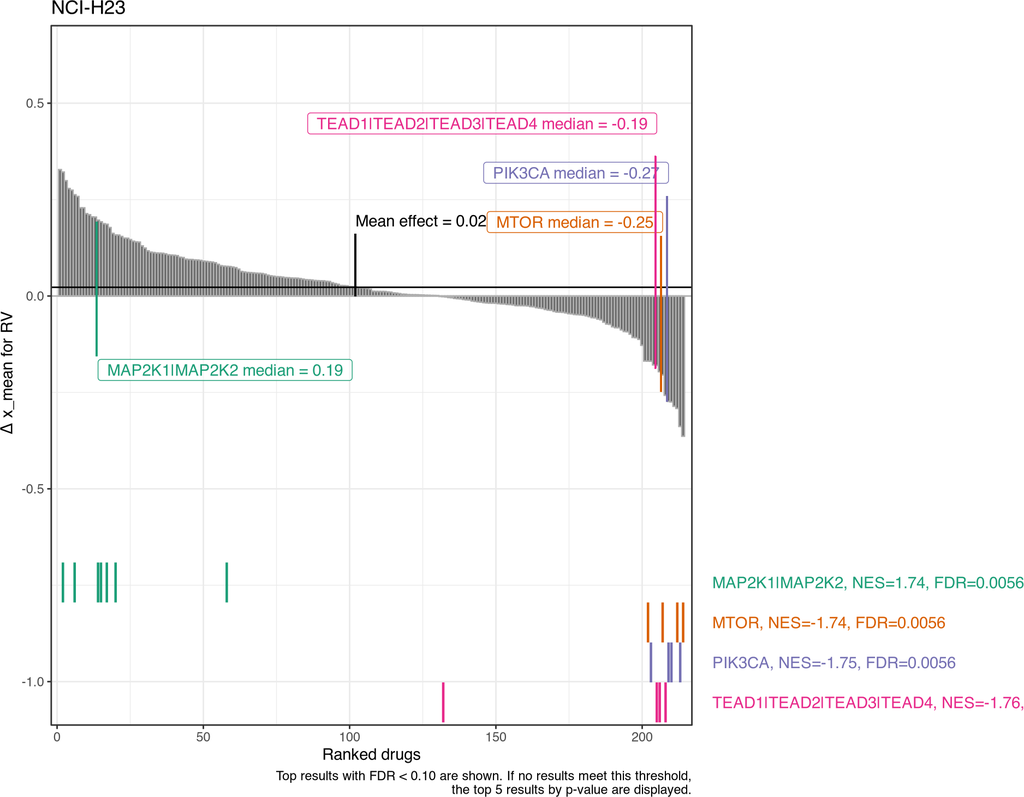

#### 6.1.1.2 x_AOC_range

🔍 Zoom In for Details

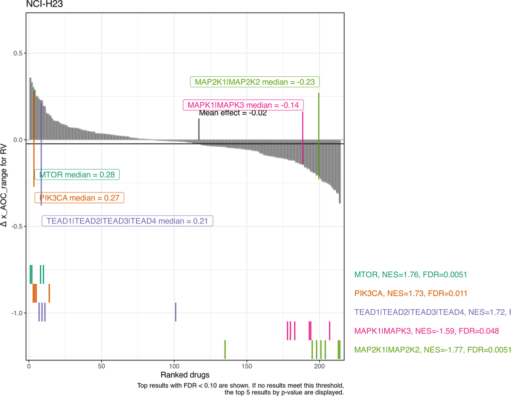

#### 6.1.1.3 xc50

🔍 Zoom In for Details

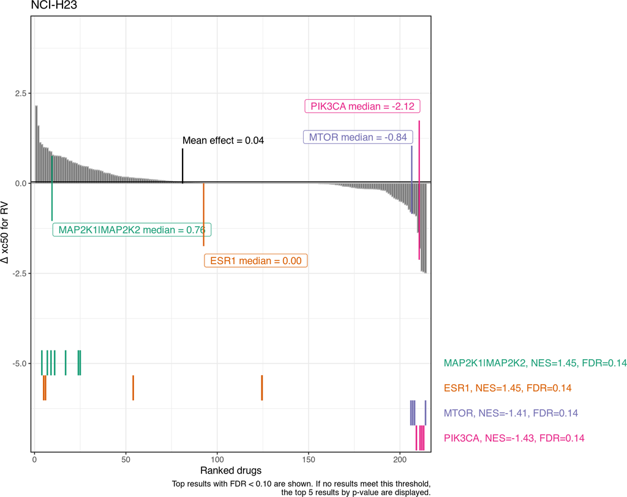

#### 6.1.1.4 ec50

🔍 Zoom In for Details

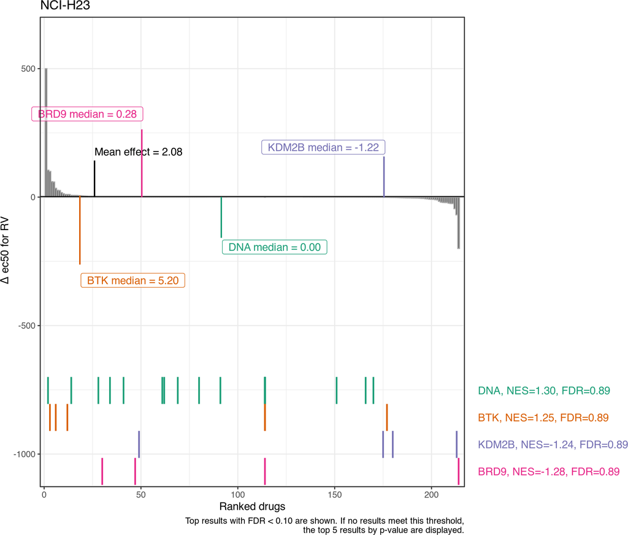

#### 6.1.1.5 x_max

🔍 Zoom In for Details

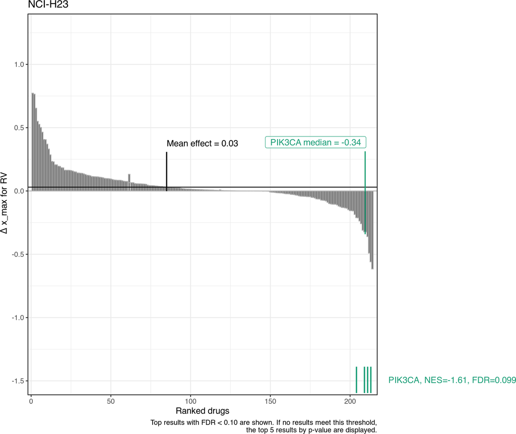

### 6.1.2 NCI-H358

#### 6.1.2.1 x_mean

🔍 Zoom In for Details

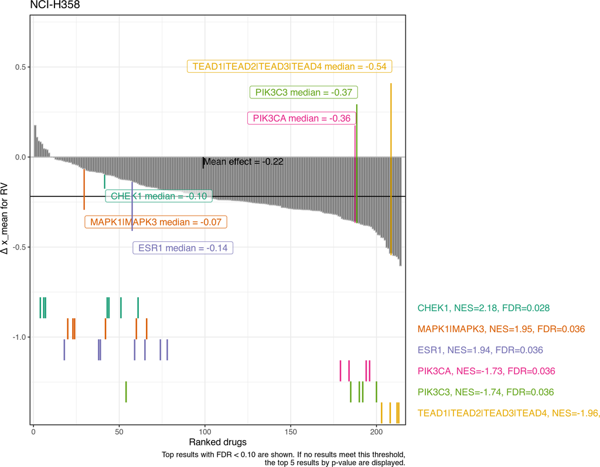

#### 6.1.2.2 x_AOC_range

🔍 Zoom In for Details

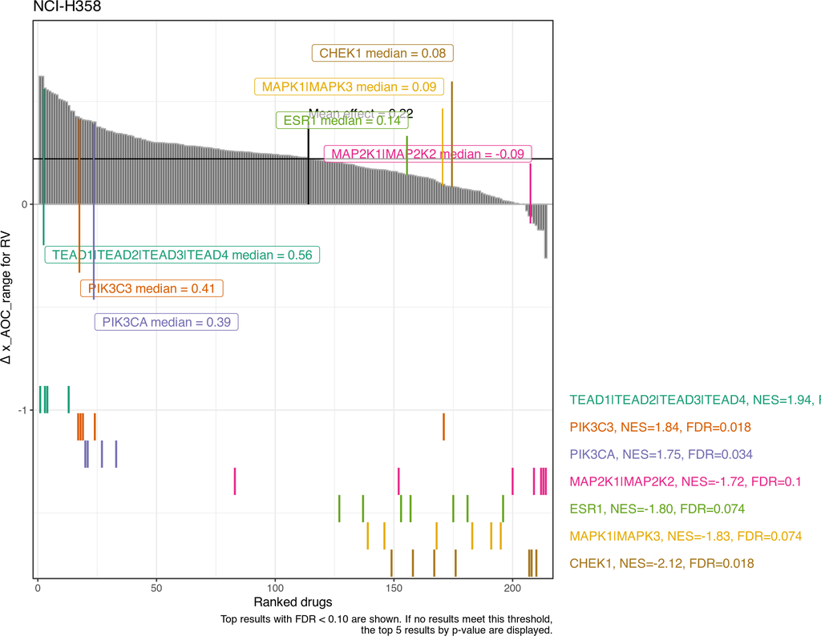

#### 6.1.2.3 xc50

🔍 Zoom In for Details

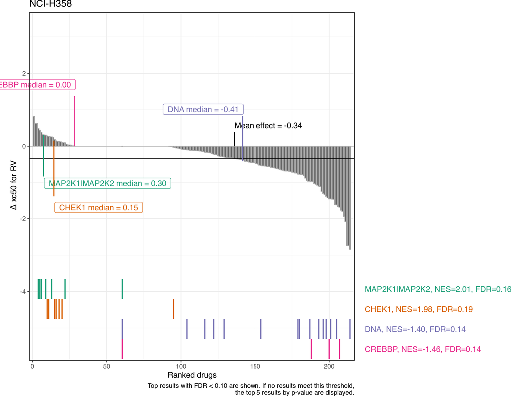

#### 6.1.2.4 ec50

🔍 Zoom In for Details

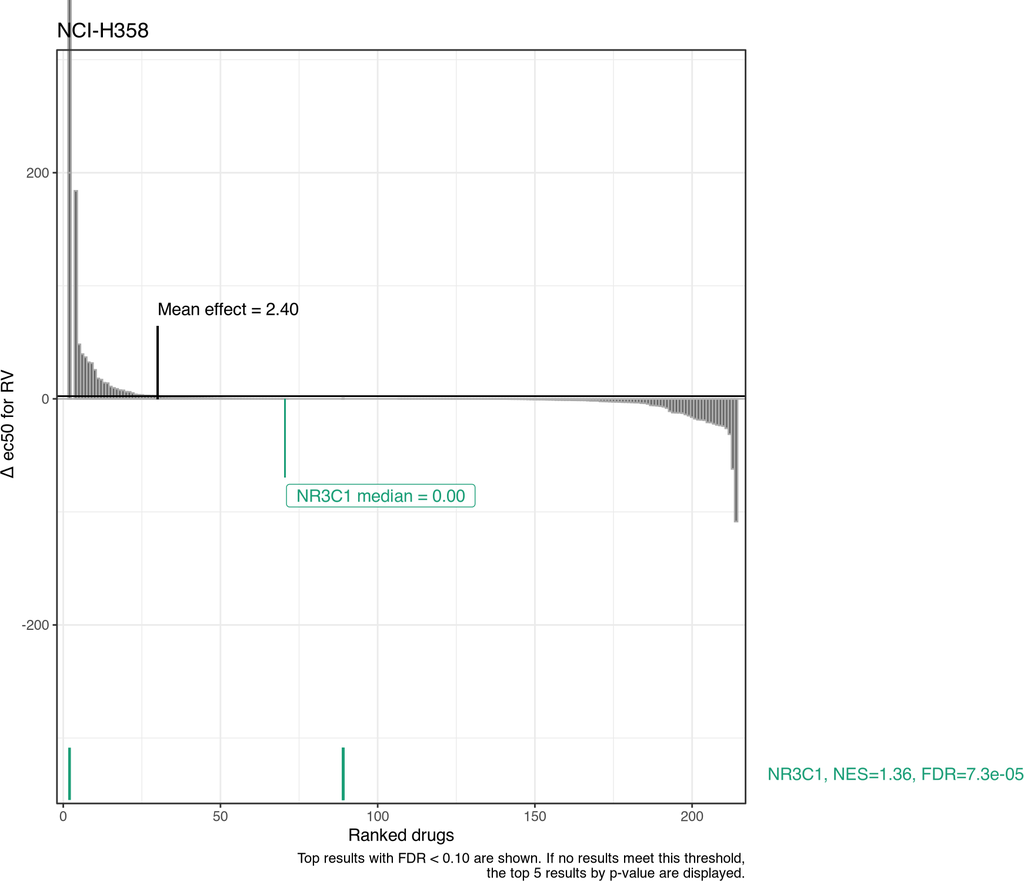

#### 6.1.2.5 x_max

🔍 Zoom In for Details

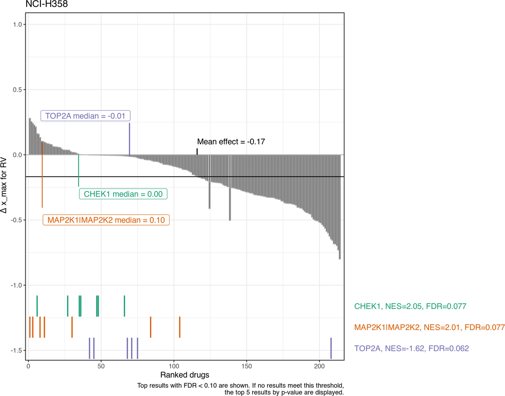

```r
nested_list_GR <- lapply(names(cgs_analysis_GR), function(cl) {
  metric_results <- lapply(analyzed_metrics, function(m) {
    plot_cgs_ranking(results = cgs_analysis_GR, cl, m)
  })
  names(metric_results) <- analyzed_metrics
  return(metric_results)
})
names(nested_list_GR) <- names(cgs_analysis_GR)
```

## 6.2 GR Value

### 6.2.1 NCI-H23

#### 6.2.1.1 x_mean

🔍 Zoom In for Details

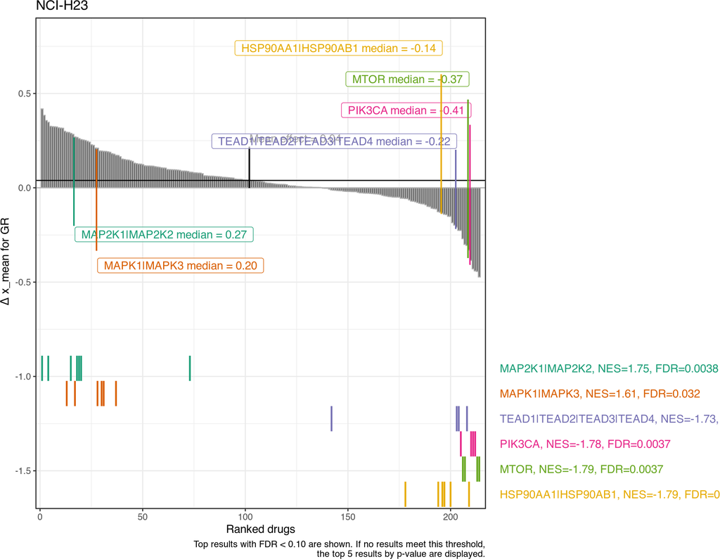

#### 6.2.1.2 x_AOC_range

🔍 Zoom In for Details

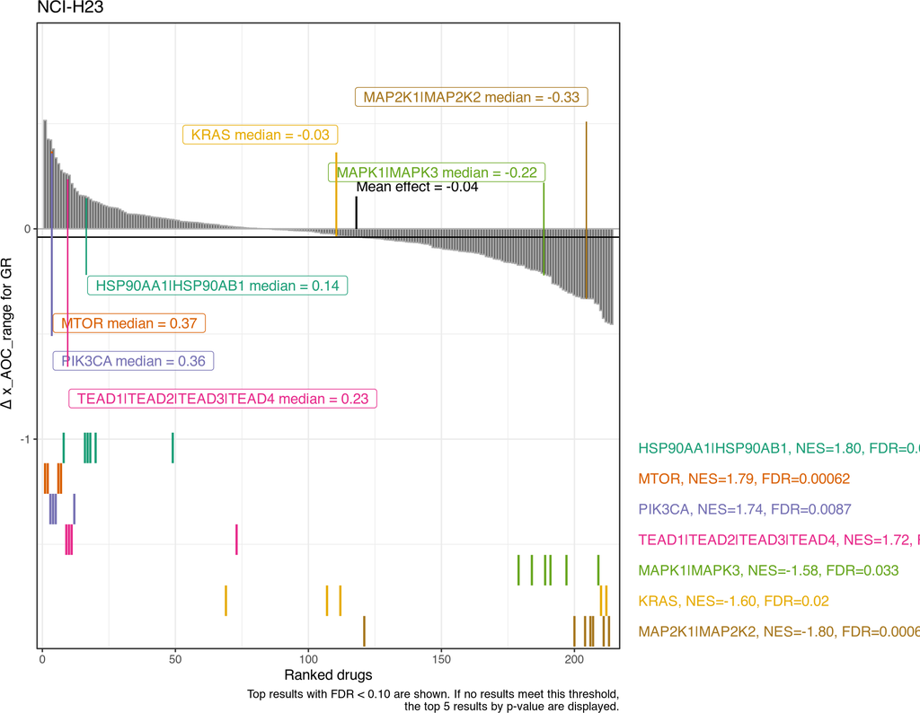

#### 6.2.1.3 xc50

🔍 Zoom In for Details

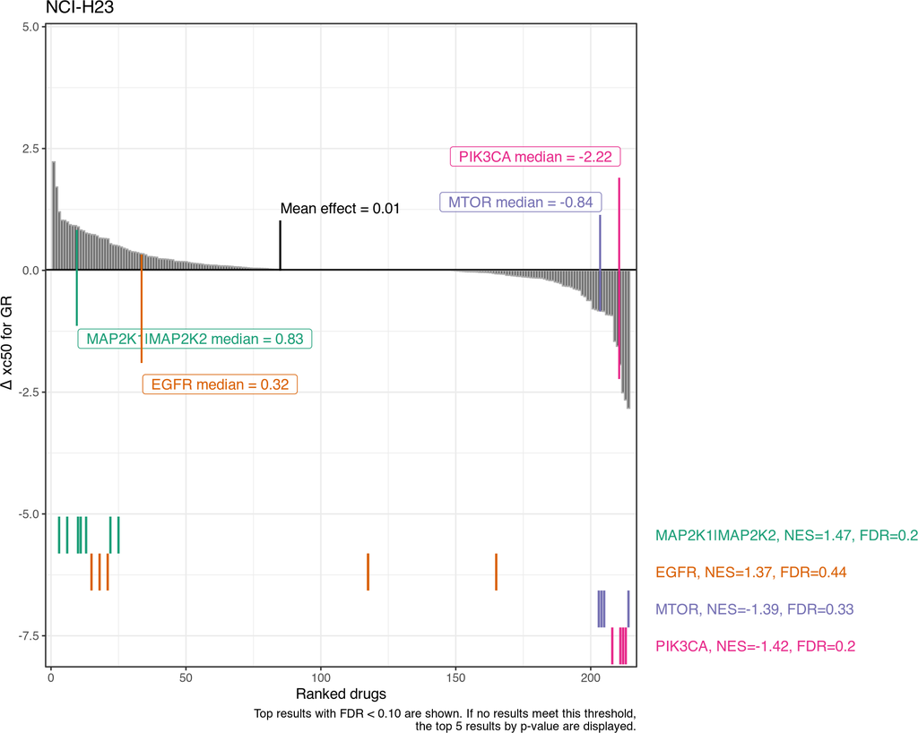

#### 6.2.1.4 ec50

🔍 Zoom In for Details

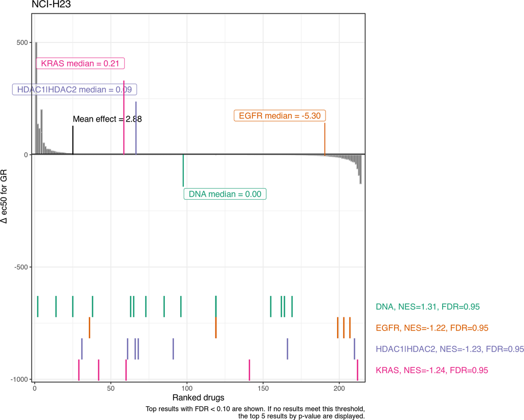

#### 6.2.1.5 x_max

🔍 Zoom In for Details

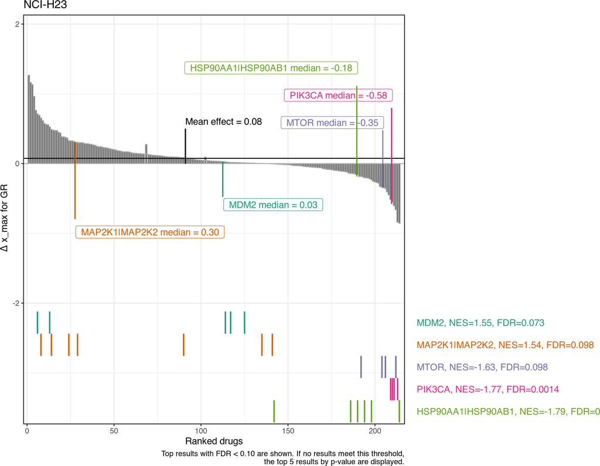

### 6.2.2 NCI-H358

#### 6.2.2.1 x_mean

🔍 Zoom In for Details

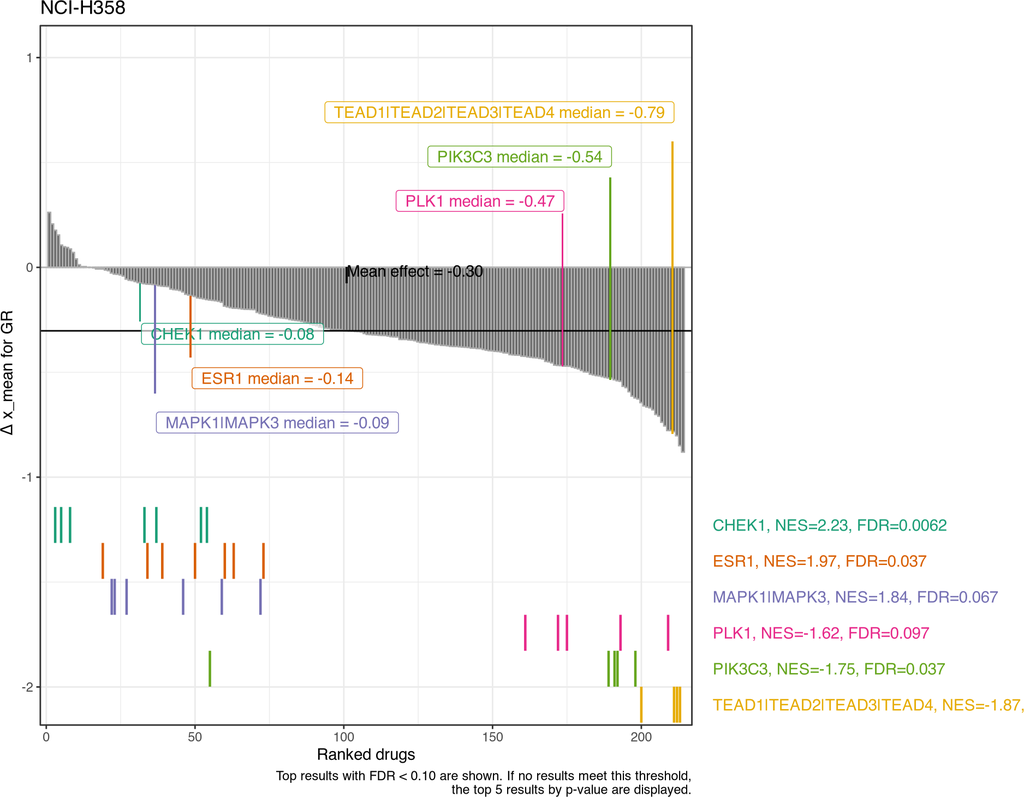

#### 6.2.2.2 x_AOC_range

🔍 Zoom In for Details

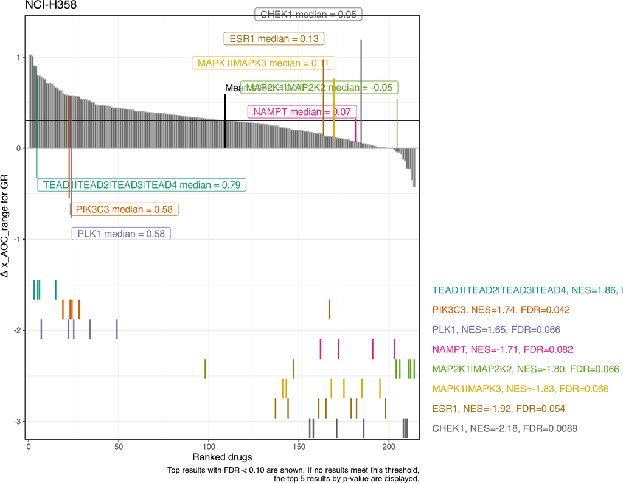

#### 6.2.2.3 xc50

🔍 Zoom In for Details

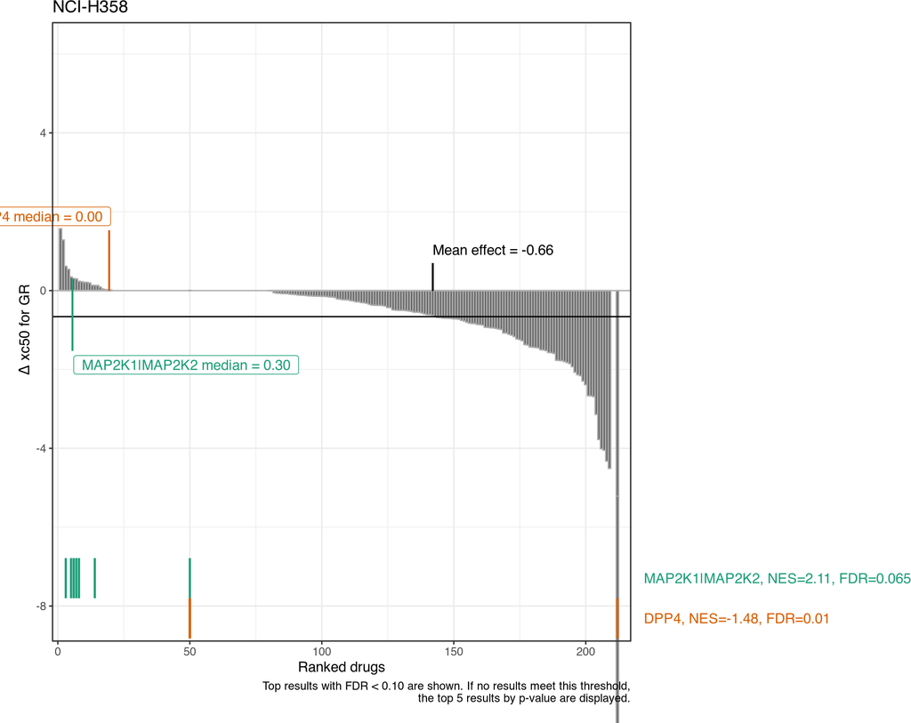

#### 6.2.2.4 ec50

🔍 Zoom In for Details

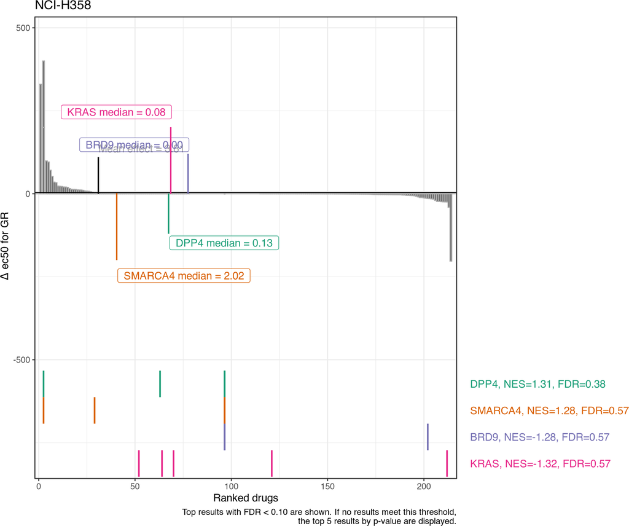

#### 6.2.2.5 x_max

🔍 Zoom In for Details

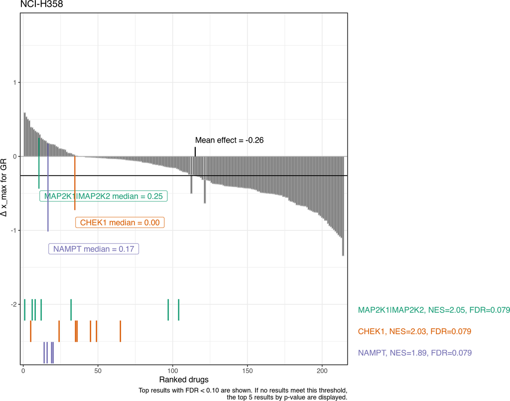

# 7 GSEA: Comparing Response Between Two Cell Lines

This second analysis is an example of how to use GSEA to compare two different cell lines. It aims to identify drug classes (MOAs) to which one cell line is significantly more or less sensitive than the other. All drugs are ranked based on the difference in their response between the two selected cell lines, and GSEA is performed on this ranked list.

*(The interpretation guide for the results table is the same as in the section above, but the NES now represents differential sensitivity between the two cell lines.)*

```r
# Run GSEA
analyzed_metrics <- "x_mean"
cell_line_name <- get_env_identifiers("cellline_name")

cellline1 <- unique(response_metrics_combo_capped[[cell_line_name]])[[1]]
cellline2 <- unique(response_metrics_combo_capped[[cell_line_name]])[[2]]
sprintf("Cell Line 1: %s; Cell Line 2: %s", cellline1, cellline2)
```

```
## [1] "Cell Line 1: NCI-H23; Cell Line 2: NCI-H358"
```

```r
cgs_analysis_RV <- analyze_cgs(response_metrics_combo_capped,
                               cellline1 = cellline1,
                               cellline2 = cellline2,
                               metrics = analyzed_metrics,
                               normalization_type = "RV")
```

## 7.1 Relative Viability

### 7.1.1 NCI-H23 vs. NCI-H358

#### 7.1.1.1 x_mean

|  | pathway | pval | padj | log2err | ES | NES | size | leadingEdge | median |
| --- | --- | --- | --- | --- | --- | --- | --- | --- | --- |
| 1 | PIK3C3 | 0.008083484279110006 | 0.2199436042040502 | 0.05884427186104315 | 0.8325358851674641 | 1.612607312830495 | 5 | ['Vps34-IN-2', 'SAR405', 'Vps34-IN-1', 'MLN Ex I-299', 'Novartis VPS34 Cpd19'] | 0.217784881964007 |
| 2 | TEAD1\|TEAD2\|TEAD3\|TEAD4 | 0.04537575919845553 | 0.2663879426034892 | 0.02501348991519281 | 0.7904761904761904 | 1.441096187641125 | 4 | ['G00836', 'GNE-7883', 'SJN 2511', 'TEAD-PPI'] | 0.2287425186861614 |
| 3 | KRAS | 0.08835059071615886 | 0.3037469020392191 | 0.01725275870730572 | 0.7067607573331043 | 1.368983110521089 | 5 | ['G00835', 'Adagrasib', 'K-Ras (G12C) inhibitor 12', 'GDC-6036'] | 0.2025041876373361 |
| 4 | DNA | 0.09346058524283664 | 0.3037469020392191 | 0.01487536345593687 | 0.5051571867241756 | 1.35661817872356 | 20 | ['cisplatin', 'OXALIPLATIN', 'Tirapazamine', 'Capecitabine', 'Carboplatin', 'Cytoxan'] | 0.06037008642744307 |
| 5 | PPARG | 0.1086763524653693 | 0.308825927394759 | 0.01578261605514645 | 0.7285714285714286 | 1.328239257283688 | 4 | ['Pioglitazone', 'GSK3787', 'Troglitazone', 'Rosiglitazone'] | 0.209614496242893 |
| 6 | MET | 0.1108605893211956 | 0.308825927394759 | 0.01561322587475723 | 0.727089778406468 | 1.325538100145917 | 4 | ['Tepotinib', 'GDC-0712'] | 0.1100354554331928 |
| 7 | DPP4 | 0.1288136070910193 | 0.3349153784366501 | 0.01438383997443599 | 0.7142857142857143 | 1.302195350278125 | 4 | ['Alogliptin', 'Vildagliptin', 'Saxagliptin', 'sitagliptin'] | 0.2200629967188126 |
| 8 | PLK1 | 0.1484360215199113 | 0.3618128024547839 | 0.01298991142949364 | 0.664069422021691 | 1.286290747652147 | 5 | ['SBE13'] | 0.0200283794551836 |
| 9 | PIM1\|PIM2 | 0.207669847792587 | 0.4719811732874878 | 0.01070841518872819 | 0.631578947368421 | 1.223357271802445 | 5 | ['GDC-0570', 'GDC-0339', 'G00194', 'G00612', 'G00600'] | 0.1504677631493687 |
| 10 | SMARCA4 | 0.2210165861082536 | 0.4719811732874878 | 0.01057814539346796 | 0.6619047619047619 | 1.206701024591063 | 4 | ['G00643', 'G00648', 'ColCN1213-19'] | 0.1590720927385258 |

[output cut: 29 more lines]

# 8 Visualizing Differential Cell Line GSEA Results

**What to look for:**

```r
nested_list_RV <- lapply(names(cgs_analysis_RV), function(cl) {
  metric_results <- lapply(analyzed_metrics, function(m) {
    plot_cgs_ranking(results = cgs_analysis_RV, cl, m)
  })
  names(metric_results) <- analyzed_metrics
  return(metric_results)
})
names(nested_list_RV) <- names(cgs_analysis_RV)
```

## 8.1 Relative Viability

### 8.1.1 NCI-H23 vs. NCI-H358

#### 8.1.1.1 x_mean

🔍 Zoom In for Details

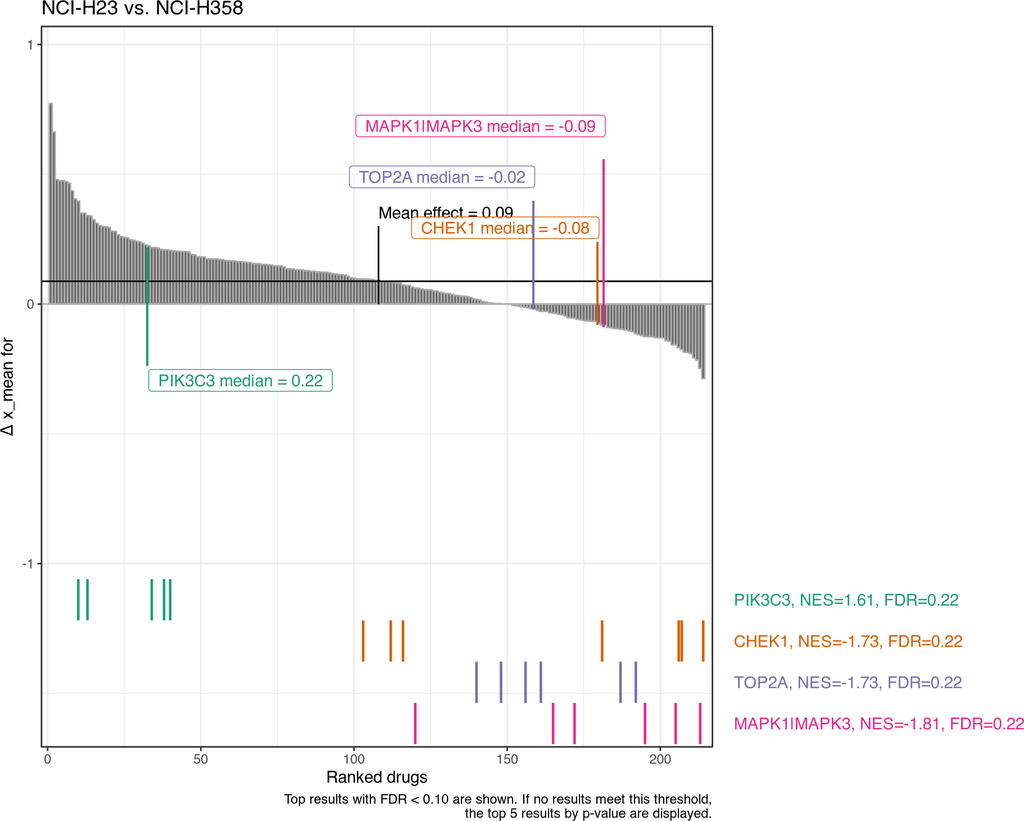

# 9 Conclusion

This report has performed a Gene Set Enrichment Analysis (GSEA) on the chemical genomics data to identify enriched drug classes based on their mechanism of action. The results highlight which drug MOAs are significantly sensitized or rescued by co-treatment, or show differential sensitivity between cell lines, providing valuable insights for further biological investigation.

### We Value Your Feedback!

Thank you for using gDR! We are always looking to improve, and your feedback is incredibly valuable to us.

[Share feedback or request features on GitHub](https://github.com/gdrplatform/gDRworkshops/issues)

# 10 gDR session info

```r
gdr_elapsed <- (proc.time() - gdr_start_time)[["elapsed"]]
message(sprintf("Report generated in %.1f seconds", gdr_elapsed))
gdr_sdt <- get_gDR_session_info()
generate_datatable(gdr_sdt)
```

|  | Package | Version |
| --- | --- | --- |
| 1 | gDR | 1.11.2 |
| 2 | gDRcomponents | 1.4.126 |
| 3 | gDRcore | 1.11.10 |
| 4 | gDRimport | 1.11.3 |
| 5 | gDRin | 0.2.96 |
| 6 | gDRinternal | 1.0.276 |
| 7 | gDRiPlots | 0.0.24 |
| 8 | gDRplots | 0.0.114 |
| 9 | gDRsearch | 1.3.40 |
| 10 | gDRsearch2 | 0.1.100 |

[output cut: 4 more lines]

```r
cat(sprintf("**Report generation time: %.1f seconds**", gdr_elapsed))
```

```
## **Report generation time: 57.0 seconds**
```